# Haser Final Project

Jack Haser

12-5-17

*Source file* ⇒ HaserFinal.Rmd

With this project I hoped to find if there is any connection between the number of colleges around ultimate frisbee teams, and if the ultimate frisbee teams are succeeding or not. Since ultimate frisbee is a mainly played by colleges I believe that there should be a connection between the two.

I Started with a table of cities and American Ultimate Disc League teams and a table of colleges. I joined these two tables to find the latitude and longitude each team was associated with. I also created a black map of america for easy viewing of the different graphics. Using the coordinates of the colleges and AUDL teams I superimposed the graphics to visualise the concentration of colleges around each team. Each team was also designated as Running or Defunct to show if they have folded or not.

College Table

| Name | Lat | Long | Status |
| --- | --- | --- | --- |
| Alabama A & M University | 34.78337 | -86.56850 | College |
| University of Alabama at Birmingham | 33.50570 | -86.79935 | College |
| Amridge University | 32.36261 | -86.17401 | College |
| University of Alabama in Huntsville | 34.72456 | -86.64045 | College |
| Alabama State University | 32.36432 | -86.29568 | College |
| University of Alabama System Office | 33.20701 | -87.52959 | College |

City Table

| City | State | Lat | Long |
| --- | --- | --- | --- |
| Dunseith | ND | 48.81306 | -100.06097 |
| Mylo | ND | 48.63528 | -99.61876 |
| Antler | ND | 48.97085 | -101.28238 |
| Bottineau | ND | 48.82723 | -100.44570 |
| Gardena | ND | 48.70084 | -100.49764 |
| Kramer | ND | 48.69056 | -100.70681 |

AUDL Table

| Team | City | State |
| --- | --- | --- |
| DC Breeze | Washington | DC |
| New York Empire | New York City | NY |
| Philadelphia Phoenix | Philadelphia | PA |
| Chicago Wildfire | Chicago | IL |
| Detroit Mechanix | Madison Heights | MI |
| Indianapolis AlleyCats | Indianapolis | IN |

Joined Table

| Team | City | State | Lat | Long |
| --- | --- | --- | --- | --- |
| DC Breeze | Washington | DC | 38.89511 | -77.03637 |
| New York Empire | New York City | NY | 40.71270 | -74.00590 |
| Philadelphia Phoenix | Philadelphia | PA | 39.95233 | -75.16379 |
| Chicago Wildfire | Chicago | IL | 41.85003 | -87.65005 |
| Detroit Mechanix | Madison Heights | MI | 42.48587 | -83.10520 |
| Indianapolis AlleyCats | Indianapolis | IN | 39.76838 | -86.15804 |

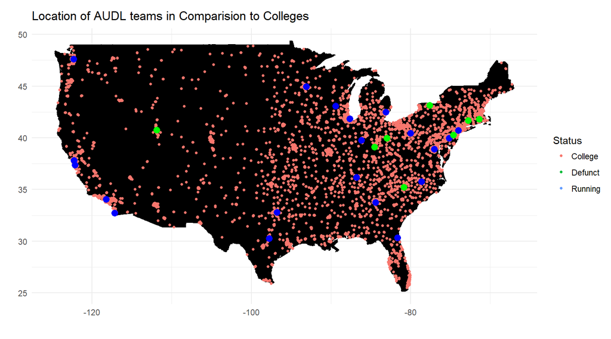

Each team was then assigned a near equal area around them, and all colleges inside of those areas were added to a count for the team. That count was then summarized to compare the amount of colleges all the individual teams had in their area, while also taking into consideration if the team has folded or not.

| Name | Lat | Long | Status | West | East | North | South |
| --- | --- | --- | --- | --- | --- | --- | --- |
| DC Breeze | 38.89511 | -77.03637 | Running | -77.28637 | -76.78637 | 39.14511 | 38.64511 |
| New York Empire | 40.71270 | -74.00590 | Running | -74.25590 | -73.75590 | 40.96270 | 40.46270 |
| Philadelphia Phoenix | 39.95233 | -75.16379 | Running | -75.41379 | -74.91379 | 40.20233 | 39.70233 |
| Chicago Wildfire | 41.85003 | -87.65005 | Running | -87.90005 | -87.40005 | 42.10003 | 41.60003 |
| Detroit Mechanix | 42.48587 | -83.10520 | Running | -83.35520 | -82.85520 | 42.73587 | 42.23587 |
| Indianapolis AlleyCats | 39.76838 | -86.15804 | Running | -86.40804 | -85.90804 | 40.01838 | 39.51838 |

| Name | Status | Count |
| --- | --- | --- |
| New York Empire | Running | 243 |
| Los Angeles Aviators | Running | 152 |
| Chicago Wildfire | Running | 116 |
| Philadelphia Phoenix | Running | 112 |
| Dallas Roughnecks | Running | 82 |
| San Francisco FlameThrowers | Running | 78 |

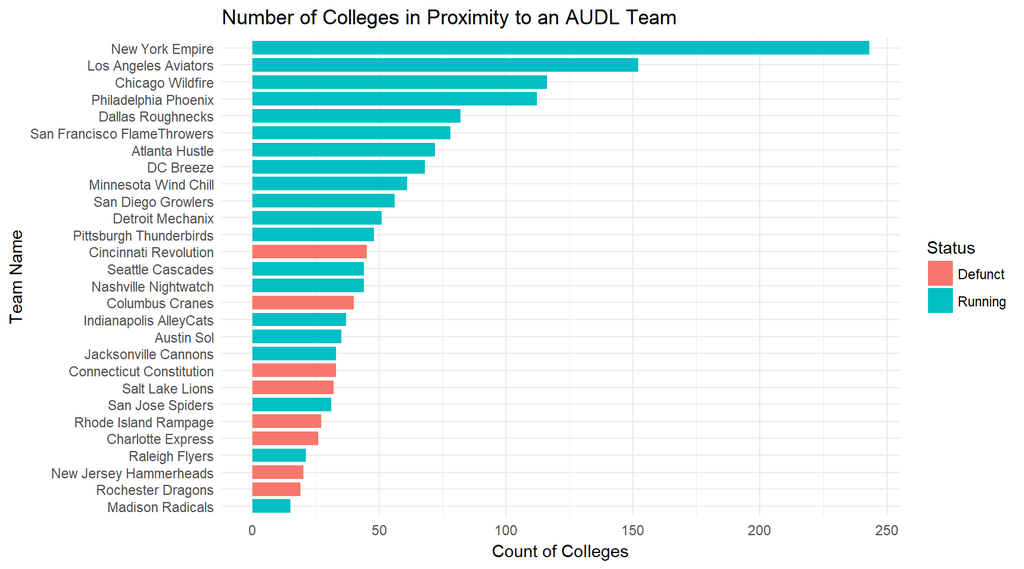

Most of the teams that have folded are in the lower half of the data for the number of surrounding colleges. I think that this can be a good indicator for determining if a team has a higher change of failing or not, although surprisingly the team with the smallest amount of colleges surrounding it is one of the the strongest and most profitable in the league so there are other factors at play, and believe this was a good way to visualize what was going on with the teams.